# Part 2: Leveraging Machine Learning and Hyperspectral Imaging for Predicting Adulteration in Ground Arabica Coffee with Robusta: Principal Component Analysis and Clustering

### Multiplicative Scatter Correction (MSC), Savitzky_Golay and 2nd Derivative Spectral Data

#### PCA Analysis: MSC+SG+2D pre-treated data

```r
pca_msc_sg_2d <- PCA(hsi_msc_2d[,c(6:229)],ncp = 60, graph = FALSE)

pca_msc_sg_2d$eig[1:60,] # Extract the first 5 component eigenvalues
```

```
          eigenvalue percentage of variance cumulative percentage of variance
comp 1  102.34164725           45.688235380                          45.68824
comp 2   56.23917739           25.106775622                          70.79501
comp 3   28.12332498           12.555055794                          83.35007
comp 4   11.83926123            5.285384479                          88.63545
comp 5    5.14033861            2.294794024                          90.93025
comp 6    3.40225587            1.518864227                          92.44911
comp 7    2.19433449            0.979613613                          93.42872
comp 8    2.14452721            0.957378217                          94.38610
comp 9    1.34007667            0.598248515                          94.98435
comp 10   1.27257958            0.568115885                          95.55247
comp 11   0.98363874            0.439124437                          95.99159
comp 12   0.97337223            0.434541175                          96.42613
comp 13   0.78102753            0.348673006                          96.77480
comp 14   0.63964557            0.285556056                          97.06036
comp 15   0.57317648            0.255882355                          97.31624
comp 16   0.51764738            0.231092579                          97.54734
comp 17   0.49477825            0.220883147                          97.76822
comp 18   0.41465542            0.185114026                          97.95333
comp 19   0.37182463            0.165993137                          98.11933
comp 20   0.32957483            0.147131619                          98.26646
comp 21   0.31998529            0.142850576                          98.40931
comp 22   0.31247275            0.139496764                          98.54880
comp 23   0.26850735            0.119869351                          98.66867
comp 24   0.24520947            0.109468513                          98.77814
comp 25   0.21083118            0.094121063                          98.87226
comp 26   0.20579936            0.091874715                          98.96414
comp 27   0.17705178            0.079040975                          99.04318
comp 28   0.14560205            0.065000913                          99.10818
comp 29   0.14373664            0.064168143                          99.17235
comp 30   0.13069190            0.058344596                          99.23069
comp 31   0.11819929            0.052767542                          99.28346
comp 32   0.10709073            0.047808361                          99.33127
comp 33   0.09533642            0.042560902                          99.37383
comp 34   0.09000784            0.040182072                          99.41401
comp 35   0.08437674            0.037668188                          99.45168
comp 36   0.07534527            0.033636279                          99.48532
comp 37   0.07066937            0.031548827                          99.51687
comp 38   0.06370062            0.028437778                          99.54530
comp 39   0.05768236            0.025751055                          99.57105
comp 40   0.05592923            0.024968407                          99.59602
comp 41   0.05084992            0.022700859                          99.61872
comp 42   0.04930622            0.022011704                          99.64073
comp 43   0.04315988            0.019267803                          99.66000
comp 44   0.04309528            0.019238962                          99.67924
comp 45   0.04173677            0.018632487                          99.69787
comp 46   0.03840581            0.017145452                          99.71502
comp 47   0.03490897            0.015584361                          99.73060
comp 48   0.03323527            0.014837173                          99.74544
comp 49   0.03228742            0.014414027                          99.75986
comp 50   0.02790695            0.012458460                          99.77231
comp 51   0.02710207            0.012099137                          99.78441
comp 52   0.02592902            0.011575454                          99.79599
comp 53   0.02434203            0.010866977                          99.80686
comp 54   0.02314193            0.010331220                          99.81719
comp 55   0.02230230            0.009956383                          99.82714
comp 56   0.02078873            0.009280682                          99.83642
comp 57   0.01871388            0.008354412                          99.84478
comp 58   0.01759798            0.007856241                          99.85263
comp 59   0.01685969            0.007526647                          99.86016
comp 60   0.01644952            0.007343537                          99.86750
```

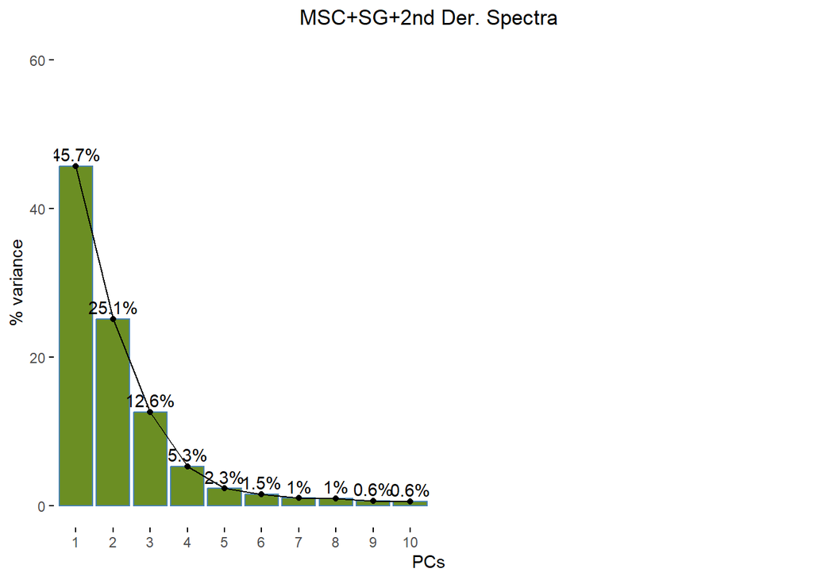

```r
# Scree Plot: Check the number of components to keep

fviz_eig(pca_msc_sg_2d, addlabels = TRUE, ylim = c(0, 60),
         xlim=c(1,20), main = 'MSC+SG+2nd Der. Spectra',barfill = "olivedrab",
         hjust = 0.5,xlab = "PCs", ylab = "% variance")+
  theme(plot.title = element_text(hjust = 0.5))+
  theme(panel.grid = element_blank())
```

```r
#Save the PCs in a new data frame
Pcs_hsi_msc_sg_2d <- as.data.frame(pca_msc_sg_2d$ind$coord[,c(1:60)])
colnames(Pcs_hsi_msc_sg_2d) <- c("PC1","PC2","PC3","PC4","PC5",
                                 "PC6","PC7","PC8","PC9","PC10",
                                 "PC11","PC12","PC13","PC14","PC15",
                                 "PC16","PC17","PC18","PC19","PC20",
                                 "P21","P22","P23","P24","PC25",
                                 "P26","PC27","PC28","PC29","PC30",
                                 "PC31","PC32","PC33","PC34","PC35",
                                 "PC36","PC37","PC38","PC39","PC40",
                                 "PC41","PC42","PC43","PC44","PC45",
                                 "PC46","PC47","PC48","PC49","PC50",
                                 "PC51","PC52","PC53","PC54","PC55",
                                 "PC56","PC57","PC58","PC59","PC60")
Pcs_hsi_msc_sg_2d <- cbind(columns, Pcs_hsi_msc_sg_2d) # Bind with the columns from initial data--> with sample details
kable(head(Pcs_hsi_msc_sg_2d))
```

| sample_id | binary_class | three_class | adult_percent | cal_val | PC1 | PC2 | PC3 | PC4 | PC5 | PC6 | PC7 | PC8 | PC9 | PC10 | PC11 | PC12 | PC13 | PC14 | PC15 | PC16 | PC17 | PC18 | PC19 | PC20 | P21 | P22 | P23 | P24 | PC25 | … |
| --- | --- | --- | --- | --- | --- | --- | --- | --- | --- | --- | --- | --- | --- | --- | --- | --- | --- | --- | --- | --- | --- | --- | --- | --- | --- | --- | --- | --- | --- | --- |
| Pure_Arabica_10 | pure_arabica | pure_arabica | 0 | 1 | -3.4014005 | 12.37823 | 12.71737 | -0.2013704 | 0.3364179 | -0.7709011 | 0.9033861 | -0.9947862 | -0.6500567 | -2.1224003 | -0.7009058 | 0.9601569 | -0.7719182 | 0.4262796 | -0.4201179 | 0.1537055 | -0.1876084 | 0.5511549 | -0.1703677 | -0.4413538 | -0.1796960 | -0.9492386 | 0.7608549 | -0.6567538 | 0.7759906 | … |
| Pure_Arabica_3 | pure_arabica | pure_arabica | 0 | 1 | 2.0679176 | 15.73442 | 14.70386 | -3.8089402 | 0.8081774 | -1.2934992 | -0.7738114 | -0.7392916 | 1.3107696 | -0.6716771 | -1.1029514 | -0.4795878 | -1.1821962 | 0.1428534 | -2.5526792 | 0.5111997 | 1.3465872 | -0.1003366 | -0.9756002 | -0.6529817 | 0.0021593 | 0.0731278 | 0.4700530 | -0.5602879 | 0.3177016 | … |
| Pure_Arabica_2 | pure_arabica | pure_arabica | 0 | 1 | -0.5808616 | 13.52767 | 17.64203 | -0.4298545 | -1.0916792 | 0.4896056 | 0.7439438 | -1.4173543 | 0.6596068 | -1.3133065 | 0.8382361 | 0.9956230 | -1.2996855 | -0.2536711 | 0.1336254 | 0.0890509 | -0.2685729 | -0.3773006 | 1.5856273 | -0.5201053 | -0.2064361 | -0.0113482 | -0.7895430 | 0.0206524 | 0.9777999 | … |
| Pure_Arabica_2 | pure_arabica | pure_arabica | 0 | 1 | -0.2053454 | 13.84743 | 18.65312 | -0.5203377 | -0.2846678 | 0.6308329 | 1.2341278 | -0.9233501 | 1.4834222 | -0.8377167 | 1.3143025 | 0.9166340 | 0.0626015 | -0.8898632 | -0.3044227 | 0.1723385 | -0.6250947 | -0.7541482 | 0.9261146 | -0.6486335 | 0.5693259 | 0.9332773 | -0.8368766 | 0.3798881 | 0.2155982 | … |
| Pure_Arabica_2 | pure_arabica | pure_arabica | 0 | 1 | 0.1140191 | 13.54787 | 14.52595 | 0.4152834 | -0.9204178 | 0.3981402 | 0.7077492 | -0.8947118 | 1.6164989 | -1.3096200 | 0.4764768 | 0.7785071 | 0.2053845 | -0.2494468 | -0.8423895 | 0.1704955 | -0.6086104 | -0.2374354 | 0.2076221 | 0.0224078 | 0.6846237 | 0.5922095 | 0.0423797 | 0.2684238 | -0.5558311 | … |
| Pure_Arabica_25 | pure_arabica | pure_arabica | 0 | 2 | -0.3183256 | 15.18330 | 17.89881 | -3.0213725 | -1.0955118 | 1.2409964 | 0.9830829 | -0.3360732 | -1.1144464 | 0.2142757 | 1.5556650 | -0.6244864 | 0.5536302 | -0.4954946 | 0.7564322 | -1.0216107 | -0.3472411 | 0.4442721 | -0.2842897 | -0.2006800 | 0.7032326 | 0.3339610 | 0.4578104 | 0.1053435 | 0.6799239 | … |

```r
#write.csv(Pcs_hsi_msc_sg_2d, file = "pcs_hsi_msc_sg_2d.csv", row.names = FALSE) #save PC data
```

**Insights: PCA-MSC+SG+2D spectral treatment**

- The first five principal components account for about 90% of the variation in the data.

#### **PCA Plot for MSC+SG+2D Spectra**

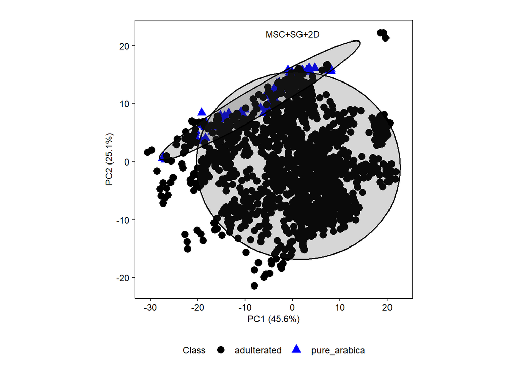

```r
# MSC+SG+2D spectra PCA Plot

Pcs_hsi_msc_sg_2d %>%
  ggplot(mapping = aes(x = PC1, y = PC2,
                       shape = as.factor(binary_class), color = binary_class)) +
  geom_point(size=3) +
  labs(x = "PC1 (45.6%)", y = "PC2 (25.1%)",
       title = "",shape = "Class", color = "Class") +
  theme_bw() +
  theme(
    panel.border = element_rect(color = 'black', fill = NA),
    panel.grid = element_blank(),
    axis.text.x = element_text(color = 'black', size = 9),
    axis.text.y = element_text(color = 'black', size = 9),
    aspect.ratio = 1,
    axis.title.x = element_text(size = 9),
    axis.title.y = element_text(size = 9),
    plot.title = element_text(size = 9, hjust = 0.5),
    legend.title = element_text(size = 9),
    legend.text = element_text(size = 9),
    legend.position = "bottom"
  ) +
  stat_ellipse(aes(group = binary_class),
               level = 0.95,
               geom = "polygon", alpha = 0.2,
               color = 'black', linewidth = 0.6)+
  scale_color_manual(values = c("pure_arabica" = "blue", "adulterated" = "black")) +
   annotate("text", x = 0, y = 22, label = "MSC+SG+2D", size = 3, color = "black")
```

#### Check Important variables contributing to PC1 and PC2 for HSI msc+SG+2nd Derivative Spectra

```r
# Let us extract the loadings from the PCA
loadings <- pca_msc_sg_2d$var$coord

# Sort the loadings for PC1 and PC2
top_PC1 <- head(sort(abs(loadings[, 1]), decreasing = TRUE), 10) # Top 10 for PC1
top_PC2 <- head(sort(abs(loadings[, 2]), decreasing = TRUE), 10)  # Top 10 for PC2

# Combine into a data frame for easy viewing
top_PC1 <- as.data.frame(top_PC1)
top_PC2 <- as.data.frame(top_PC2)

# Display the top contributing variables
kable(top_PC1)
```

|  | top_PC1 |
| --- | --- |
| X1333.219971 | 0.9672573 |
| X1224.369995 | 0.9607636 |
| X1252.410034 | 0.9558480 |
| X1255.920044 | 0.9552578 |
| X1336.73999 | 0.9521321 |
| X1220.869995 | 0.9497682 |
| X1248.900024 | 0.9442438 |
| X973.650024 | 0.9434675 |
| X1199.869995 | 0.9425191 |
| X1259.420044 | 0.9419573 |

```r
kable(top_PC2)
```

|  | top_PC2 |
| --- | --- |
| X1424.920044 | 0.9700669 |
| X1421.390015 | 0.9503190 |
| X1287.51001 | 0.9392701 |
| X1283.98999 | 0.9349863 |
| X1389.609985 | 0.9279831 |
| X1393.140015 | 0.9203150 |
| X1291.02002 | 0.9181747 |
| X1305.079956 | 0.9069544 |
| X1308.589966 | 0.9051351 |
| X1294.530029 | 0.9023163 |

- The variance in **PC1** is largely contributed by wavelengths regions around **1220-1259 nm** and **1333-1336 nm**, while regions **1287-1308 nm** and **1389 - 1424 nm** contribute to PC2.

#### K-Means Clustering: MSC+SG+2nd Derivative Spectra

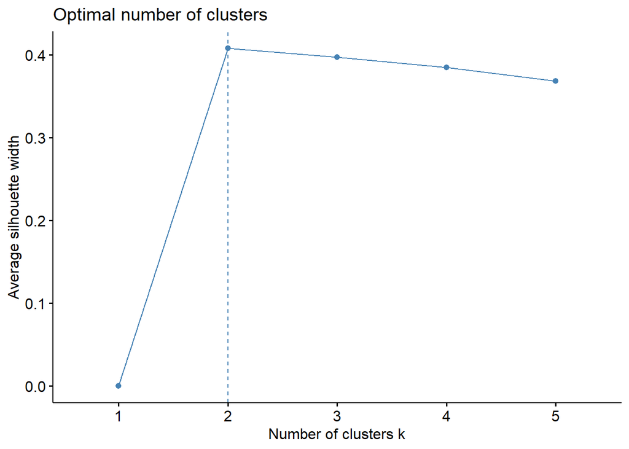

```r
# Use PCA reduced data to first determine the number of clusters  by silhouette method

# optimal number of clusters for HSI
msc_sg_2d_clust<-fviz_nbclust(Pcs_hsi_msc_sg_2d[,c(6,7)],
                        kmeans, method = "silhouette", k.max=5)

print(msc_sg_2d_clust) #determine the number of clusters
```

```r
# Perform K-Means Classification using the optimal number of clusters
msc_sg_2d_kmeans <- kmeans(Pcs_hsi_msc_sg_2d[,c(6,7)],centers = 2, iter.max = 10,nstart = 25)
msc_sg_2d_clusters <- as.factor(msc_sg_2d_kmeans$cluster) # Extract clusters
```

[figure not shown]

```r
# Add the cluster assignments to the data frame
Pcs_hsi_msc_sg_2d$Cluster <- msc_sg_2d_clusters

# Visualize the clusters
ggplot(Pcs_hsi_msc_sg_2d, aes(x = PC1, y = PC2, color = Cluster, shape = as.factor(binary_class))) +
  geom_point(size = 3) +
  labs(x = "PC1", y = "PC3", title = "K-Means Clustering on MSC+SG+2Der. Spectra Data", shape = 'Class') +
 scale_color_manual(values = c("#33a",  "#e31a1c")) +
  theme_minimal() +
  theme(panel.border = element_rect(color = 'black', fill = NA),
        panel.grid = element_blank(),
        axis.text.x = element_text(color = 'black', size = 10),
        axis.text.y = element_text(color = 'black', size = 10),
        aspect.ratio = 1,
        axis.title.x = element_text(size = 9),
        axis.title.y = element_text(size = 9),
        legend.title = element_text(size = 9),
        plot.title = element_text(size = 10, hjust = 0.5))
```

```r
# Create a confusion matrix
cfmatrix_msc_sg_2d<-confusionMatrix(as.factor(msc_sg_2d_clusters),as.factor(class_k))

cfmatrix_msc_sg_2d #display the confusion matrix
```

```
Confusion Matrix and Statistics

          Reference
Prediction   1   2
         1 397  40
         2 997  35

               Accuracy : 0.2941
                 95% CI : (0.2709, 0.3181)
    No Information Rate : 0.9489
    P-Value [Acc > NIR] : 1

                  Kappa : -0.0353

 Mcnemar's Test P-Value : <2e-16

            Sensitivity : 0.28479
            Specificity : 0.46667
         Pos Pred Value : 0.90847
         Neg Pred Value : 0.03391
             Prevalence : 0.94894
         Detection Rate : 0.27025
   Detection Prevalence : 0.29748
      Balanced Accuracy : 0.37573

       'Positive' Class : 1
```

```r
kable(cfmatrix_msc_sg_2d$byClass)
```

|  | x |
| --- | --- |
| Sensitivity | 0.2847920 |
| Specificity | 0.4666667 |
| Pos Pred Value | 0.9084668 |
| Neg Pred Value | 0.0339147 |
| Precision | 0.9084668 |
| Recall | 0.2847920 |
| F1 | 0.4336428 |
| Prevalence | 0.9489449 |
| Detection Rate | 0.2702519 |
| Detection Prevalence | 0.2974813 |
| Balanced Accuracy | 0.3757293 |

## Conclusion

PCA and K-Means were successfully applied to both raw and preprocessed spectral data as part of the exploratory analysis. These unsupervised techniques provided initial insights into the underlying structure of the dataset by reducing dimensionality (PCA) and grouping samples based on similarity (K-Means). However, the results demonstrated that neither method could distinctly separate or enable effective visualization of the two expected clusters: pure and adulterated coffee samples.

This outcome suggests that the spectral differences between pure and adulterated coffee, even after preprocessing, might be subtle, complex, or nonlinear, making them challenging to capture using traditional unsupervised methods. The preprocessing techniques applied, including Standard Normal Variate (SNV), Savitzky-Golay smoothing, and derivatives], were aimed at enhancing signal quality and reducing noise but may require further optimization or combination with advanced feature extraction methods.

To overcome these challenges, supervised learning approaches such as Support Vector Machines (SVM), Partial Least Squares Discriminant Analysis (PLS-DA), or Random Forest will be explored. These methods utilize labeled data to maximize class separability, making them more suitable for distinguishing between pure and adulterated samples.

The findings underscore the limitations of relying solely on unsupervised methods and highlight the importance of leveraging supervised techniques to better exploit the data. The next steps will focus on applying advanced supervised methods to evaluate the ability of hyperspectral imaging techniques in detecting adulteration of Arabica coffee.